# Module contrasts: HR against LR

The co-expression modules from `01_Processing/06_Module_Building` are tested in the nine contrasts of the protein fit in two ways. The eigengene test fits limma to each module’s eigengene (one number per biopsy). The set test runs fry on each module’s proteins as a set, the way `02_Set_Contrasts` tests gene sets. A third table describes, within each module, whether the members that follow the module most closely are also the ones that changed most.

## Packages

```r
library(here)
library(limma)
library(dplyr)
library(tidyr)
library(purrr)
library(ggplot2)
source(here("00_Setup", "Shared_functions", "workbooks.R"))
inputs <- c(
  modules = "01_Processing/06_Module_Building/c_data/module_building.rds",
  fit = "02_HRvLR/01_Protein_Contrasts/c_data/protein_contrasts.rds"
)
paths <- vapply(inputs, here, character(1))
stopifnot(file.exists(paths))
```

## Input

The eigengenes (module by biopsy) and membership, and the protein fit with its design, contrasts and moderated t values.

```r
modules <- readRDS(paths[["modules"]])
saved <- readRDS(paths[["fit"]])
me <- modules$eigengenes
meta <- as_tibble(saved$fit$EList$targets)
contrasts <- colnames(saved$contrast_matrix)
members <- filter(modules$membership, module != "grey")
module_order <- modules$module_summary$module
stopifnot(identical(colnames(me), meta$sample_id), nrow(saved$design) == nrow(meta))
modules$module_summary
```

```
# A tibble: 10 × 3
   module    n_proteins    icc
   <chr>          <int>  <dbl>
 1 turquoise        340 0.0947
 2 blue             330 0.0859
 3 brown            249 0.0203
 4 yellow           211 0.119
 5 green            168 0
 6 red              167 0.268
 7 black            109 0.137
 8 pink             104 0.208
 9 magenta           82 0.0227
10 purple            70 0.139
```

## Eigengene tests

Each eigengene goes through the protein design: one mean per group and time point plus the blood index, person as a block. The within-person correlation is estimated on the eigengenes themselves (`duplicateCorrelation()`), since they are the values fitted. limpa’s sample weights belong to the protein values and are not used here. `df` is limma’s total degrees of freedom (the heatmap turns t into an r-equivalent with it). `fdr` is Benjamini-Hochberg across modules within a contrast.

```r
me_correlation <- duplicateCorrelation(me, saved$design, block = meta$subject)$consensus.correlation
me_fit <- lmFit(me, saved$design, block = meta$subject, correlation = me_correlation) |>
  contrasts.fit(saved$contrast_matrix) |>
  eBayes(robust = TRUE)
eigengene_tests <- map(set_names(contrasts), \(cn) {
  topTable(me_fit, coef = cn, number = Inf, sort.by = "none", confint = TRUE) |>
    as_tibble(rownames = "module") |>
    transmute(
      module, logFC, logFC_lower = CI.L, logFC_upper = CI.R, t,
      df = me_fit$df.total[match(module, rownames(me_fit))], p = P.Value, fdr = adj.P.Val
    )
}) |>
  list_rbind(names_to = "contrast")
c(within_person_correlation = round(me_correlation, 3))
```

```
within_person_correlation
                    0.087
```

```r
slice_min(eigengene_tests, p, n = 5)
```

```
# A tibble: 5 × 9
  contrast      module   logFC logFC_lower logFC_upper     t    df      p   fdr
  <chr>         <chr>    <dbl>       <dbl>       <dbl> <dbl> <dbl>  <dbl> <dbl>
1 Acute_HRvLR   magenta -0.162    -0.308      -0.0151  -2.17   410 0.0307 0.175
2 Acute_HRvLR   red     -0.158    -0.304      -0.0112  -2.12   410 0.0349 0.175
3 Acute_HR      pink    -0.149    -0.289      -0.00901 -2.09   410 0.0370 0.220
4 Training_HR   magenta  0.139     0.00215     0.276    2.00   410 0.0465 0.236
5 Trained_HRvLR yellow  -0.146    -0.290      -0.00208 -1.99   410 0.0468 0.468
```

## Modules as protein sets

fry receives limpa’s values and weights (`fit$EList`), the protein design, the contrast, the person block and the within-person correlation of the protein fit. It asks whether a module’s proteins move together in the contrast, with people as the unit. `fdr` runs across modules within a contrast.

```r
module_rows <- split(match(members$uniprot_id, rownames(saved$fit$EList)), members$module)
stopifnot(!any(map_lgl(module_rows, anyNA)))
fry_tests <- map(set_names(contrasts), \(cn) {
  fry(
    saved$fit$EList,
    index = module_rows, design = saved$design, contrast = saved$contrast_matrix[, cn],
    block = meta$subject, correlation = saved$fit$correlation, sort = "none"
  ) |>
    as_tibble(rownames = "module") |>
    transmute(module, n_proteins = NGenes, direction = Direction, p = PValue, fdr = FDR)
}) |>
  list_rbind(names_to = "contrast")
slice_min(fry_tests, p, n = 5)
```

```
# A tibble: 5 × 6
  contrast    module  n_proteins direction       p    fdr
  <chr>       <chr>        <int> <chr>       <dbl>  <dbl>
1 Acute_LR    yellow         211 Down      0.00850 0.0331
2 Acute_LR    brown          249 Down      0.00944 0.0331
3 Acute_LR    pink           104 Down      0.00994 0.0331
4 Training_HR magenta         82 Up        0.0133  0.0886
5 Training_HR red            167 Up        0.0177  0.0886
```

## Membership against protein change

Within each module, Spearman’s rho between a member’s kME (how closely it follows the eigengene) and its moderated t in the contrast. A positive rho means the module’s most central proteins moved up most. Members were grouped by co-variation, so rho and its p describe the module; they do not test it.

```r
protein_t <- as_tibble(saved$eb$t, rownames = "uniprot_id") |>
  pivot_longer(-uniprot_id, names_to = "contrast", values_to = "t")
membership_contrast <- members |>
  inner_join(protein_t, by = "uniprot_id", relationship = "one-to-many") |>
  summarise(
    n_members = n(), rho = cor(kme, t, method = "spearman"),
    p = cor.test(kme, t, method = "spearman", exact = FALSE)$p.value, .by = c(module, contrast)
  )
slice_max(membership_contrast, abs(rho), n = 5)
```

```
# A tibble: 5 × 5
  module  contrast    n_members    rho        p
  <chr>   <chr>           <int>  <dbl>    <dbl>
1 black   Training_HR       109 -0.629 2.46e-13
2 magenta Training_HR        82  0.507 1.20e- 6
3 red     Training_HR       167  0.480 5.51e-11
4 brown   Acute_LR          249 -0.425 2.57e-12
5 magenta Acute_HRvLR        82 -0.417 9.73e- 5
```

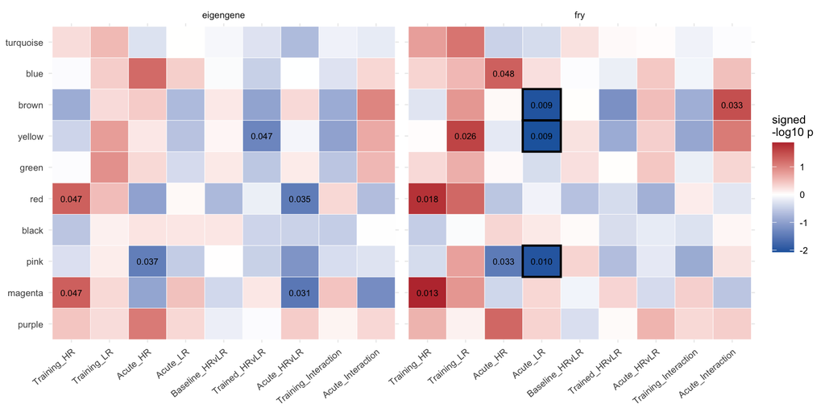

Figure 1: Signed -log10 p per module and contrast; black border: FDR < 0.05; label: p < 0.05.

```r
bind_rows(
  eigengene = transmute(eigengene_tests, contrast, module, signed = -log10(p) * sign(t), p, fdr),
  fry = transmute(
    fry_tests, contrast, module,
    signed = -log10(p) * if_else(direction == "Up", 1, -1), p, fdr
  ),
  .id = "test"
) |>
  mutate(module = factor(module, rev(module_order)), contrast = factor(contrast, contrasts)) |>
  ggplot(aes(contrast, module, fill = signed)) +
  geom_tile(colour = "white") +
  geom_tile(data = \(d) filter(d, fdr < 0.05), colour = "black", linewidth = 0.8, fill = NA) +
  geom_text(aes(label = if_else(p < 0.05, sprintf("%.3f", p), "")), size = 2.4) +
  scale_fill_gradient2(low = "#2166AC", high = "#B2182B", name = "signed\n-log10 p") +
  facet_wrap(~test) +
  labs(x = NULL, y = NULL) +
  theme_minimal(base_size = 9) +
  theme(axis.text.x = element_text(angle = 40, hjust = 1))
```

## Validation

```r
stopifnot(
  nrow(eigengene_tests) == nrow(me) * length(contrasts),
  nrow(fry_tests) == nrow(me) * length(contrasts),
  setequal(names(module_rows), rownames(me)),
  all(eigengene_tests$fdr >= eigengene_tests$p), all(fry_tests$fdr >= fry_tests$p),
  all(abs(membership_contrast$rho) <= 1)
)
```

## Summary

10 modules in 9 contrasts. Eigengene tests: 6 at p < 0.05 and 0 at FDR < 0.05. fry: 9 at p < 0.05 and 3 at FDR < 0.05. Chance alone gives about 4.5 per method at p < 0.05. Within-person correlation 0.087 on the eigengenes, 0.178 in the protein fit.

## Save

`module_contrasts.rds` holds the three tables for the figures.

```r
out <- here("02_HRvLR", "03_Module_Contrasts", "c_data")
dir.create(out, showWarnings = FALSE)
saveRDS(
  list(
    eigengene_tests = eigengene_tests, fry_tests = fry_tests,
    membership_contrast = membership_contrast
  ),
  file.path(out, "module_contrasts.rds")
)
write_workbook(
  list(
    eigengene_tests = eigengene_tests, fry_tests = fry_tests,
    membership_contrast = membership_contrast
  ),
  c(
    "limma on module eigengenes: logFC with 95% CI, moderated t, p, FDR across modules.",
    "fry on each module's proteins: direction, p, FDR across modules.",
    "Spearman rho between member kME and protein moderated t, per module and contrast."
  ),
  file.path(out, "module_contrasts.xlsx"), inputs, paths
)
```